# Community Contribution

Hao Wu; UNI:hw2664

3/22/2019

## Introduction

Mosaicplot is a useful way to visualize multivariate categorical data. In R, there are several functions from different packages to draw mosaicplot. In this analysis, I will compare the **geom_mosaic** function from ggmosaic package and the **mosaic** function from vcd function. I will use the built-in dataset called *Titanic* to draw the plots.

## Data description

The *Titanic* dataset summarizes the information on the fate of passengers on the fatal maiden voyage of the ocean liner Titanic. In this dataset, there are four variables, which are Class, Sex, Age and Survived. For **Class** variable, it records which class a passenger belongs to and has four levels, which are first class, second class, third class, and crew members. For **Sex** variable, it has two categories, which are male and female. For **Age** variable, it has two categories, which are child and adult. For **Survived** categories, it records whether the passager survived or not.

The *Titanic* dataset in R is a 4-dimensional array. it records the number of people in each combination of the four variables. For example, the number of children who did not survive, are male, and belong to first class is 0.

The *Titanic* dataset are shown below.

```r
Titanic
```

```
## , , Age = Child, Survived = No
##
##       Sex
## Class  Male Female
##   1st     0      0
##   2nd     0      0
##   3rd    35     17
##   Crew    0      0
##
## , , Age = Adult, Survived = No
##
##       Sex
## Class  Male Female
##   1st   118      4
##   2nd   154     13
##   3rd   387     89
##   Crew  670      3
##
## , , Age = Child, Survived = Yes
##
##       Sex
## Class  Male Female
##   1st     5      1
##   2nd    11     13
##   3rd    13     14
##   Crew    0      0
##
## , , Age = Adult, Survived = Yes
##
##       Sex
## Class  Male Female
##   1st    57    140
##   2nd    14     80
##   3rd    75     76
##   Crew  192     20
```

## Examples using geom_mosaic function from ggmosaic package

At first, I will use **geom_mosaic** function to draw the mosaicplot. Before drawing the mosaicplot, we need to convert the dataset into data frame since ggplot only accepts data frame. If we directly use the dataset in an array form, R will give us an error, which is *“data must be a data frame, or other object coercible by fortify(), not an S3 object with class table”*.

```r
library(ggplot2)
library(ggmosaic)
#convert array into data frame
Titanic.df <- data.frame(Titanic)
```

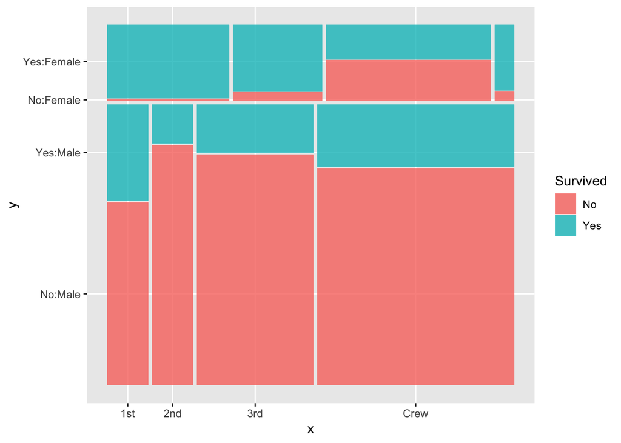

```r
ggplot(data = Titanic.df) +
  geom_mosaic(aes(weight=Freq, x=product(Class, Sex), fill=Survived), divider = mosaic("v"))
```

The mosaicplot above shows the Survived variable depends on class and sex. In the **geom_mosaic** function, I define a aesthetic that uses the frequency for the weight of each combination and specifies class and sex as independent variables. I also specify different color to represent the dependent variable by using fill argument. divider argument specifies the direction of the first split is vertical.

It is worth to notice that, we need to set aesthetic in the **geom_mosaic()** instead of **ggplot()**. If we set aesthetic in **ggplot()**, we will get an error, which is *“mapping must be created by aes()”*.

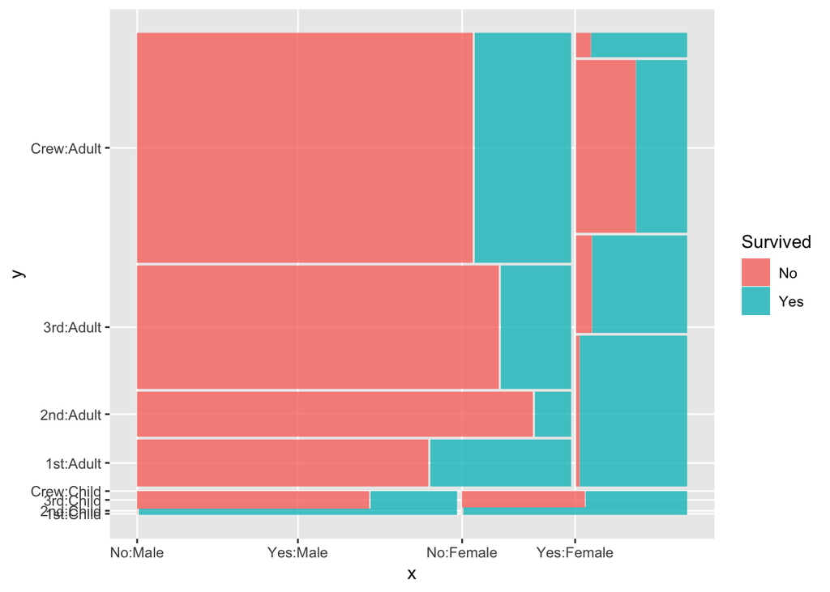

```r
ggplot(data = Titanic.df) +
  geom_mosaic(aes(weight=Freq, x=product(Class, Sex, Age), fill=Survived), divider = mosaic("v"))
```

The mosaicplot above shows the Survived variable depends on class, sex, and age.

## Examples using mosaic function from vcd package

Next, I will use **mosaic** function to draw the mosaicplot. Unlike ggplot, the **mosaic** function can directly take the data in an array form, which is convenient.

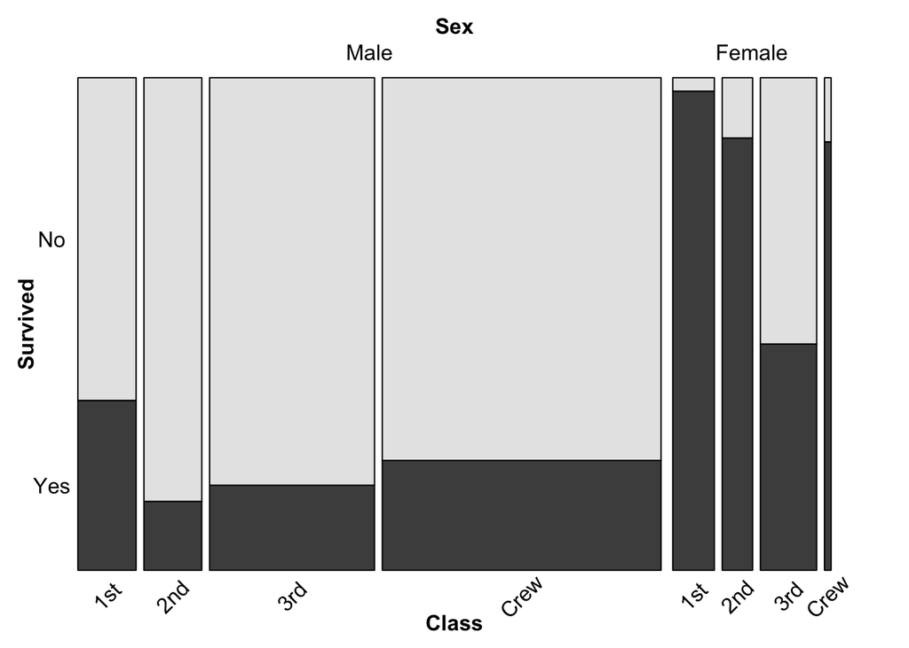

```r
vcd::mosaic(Survived~Sex+Class, data = Titanic, direction = c("v","v","h"), rot_labels = c(0, 0, 45, 0))
```

The mosaicplot above shows the Survived variable depends on class and sex. In the **mosaic** function, I define a formula to specify the variables used to create a contingency table from data argument. For the formula, I specify a dependent variable before the tilde sign, and the variables after the tilde sign will be independent variables. Then I specify the direction of each split, “v” for vertical split and “h” for horizontal split. We can use rot_labels to solve overlap issue beween labels.

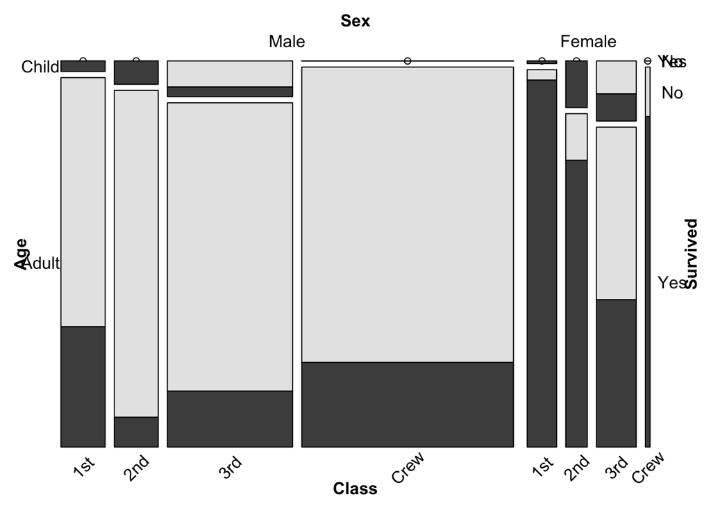

```r
vcd::mosaic(Survived~Sex+Class+Age, data = Titanic, direction = c("v","v","h","h"), rot_labels = c(0, 0, 45, 0))
```

The mosaicplot above shows the Survived variable depends on class, sex, and age.